# CMPINF 2130 Summer 2022 - Week 02

aesthetic deep dive

Dr. Joseph P. Yurko

2022-05-24

## Load packages

```r
library(tidyverse)
```

## Anscombe

```r
anscombe %>% glimpse()
```

```
## Rows: 11
## Columns: 8
## $ x1 <dbl> 10, 8, 13, 9, 11, 14, 6, 4, 12, 7, 5
## $ x2 <dbl> 10, 8, 13, 9, 11, 14, 6, 4, 12, 7, 5
## $ x3 <dbl> 10, 8, 13, 9, 11, 14, 6, 4, 12, 7, 5
## $ x4 <dbl> 8, 8, 8, 8, 8, 8, 8, 19, 8, 8, 8
## $ y1 <dbl> 8.04, 6.95, 7.58, 8.81, 8.33, 9.96, 7.24, 4.26, 10.84, 4.82, 5.68
## $ y2 <dbl> 9.14, 8.14, 8.74, 8.77, 9.26, 8.10, 6.13, 3.10, 9.13, 7.26, 4.74
## $ y3 <dbl> 7.46, 6.77, 12.74, 7.11, 7.81, 8.84, 6.08, 5.39, 8.15, 6.42, 5.73
## $ y4 <dbl> 6.58, 5.76, 7.71, 8.84, 8.47, 7.04, 5.25, 12.50, 5.56, 7.91, 6.89
```

```r
anscombe
```

```
##    x1 x2 x3 x4    y1   y2    y3    y4
## 1  10 10 10  8  8.04 9.14  7.46  6.58
## 2   8  8  8  8  6.95 8.14  6.77  5.76
## 3  13 13 13  8  7.58 8.74 12.74  7.71
## 4   9  9  9  8  8.81 8.77  7.11  8.84
## 5  11 11 11  8  8.33 9.26  7.81  8.47
## 6  14 14 14  8  9.96 8.10  8.84  7.04
## 7   6  6  6  8  7.24 6.13  6.08  5.25
## 8   4  4  4 19  4.26 3.10  5.39 12.50
## 9  12 12 12  8 10.84 9.13  8.15  5.56
## 10  7  7  7  8  4.82 7.26  6.42  7.91
## 11  5  5  5  8  5.68 4.74  5.73  6.89
```

Start working with the first dataset within Anscombe.

```r
anscombe %>%
  select(x1, y1)
```

```
##    x1    y1
## 1  10  8.04
## 2   8  6.95
## 3  13  7.58
## 4   9  8.81
## 5  11  8.33
## 6  14  9.96
## 7   6  7.24
## 8   4  4.26
## 9  12 10.84
## 10  7  4.82
## 11  5  5.68
```

```r
anscombe %>%
  select(x = x1, y = y1)
```

```
##     x     y
## 1  10  8.04
## 2   8  6.95
## 3  13  7.58
## 4   9  8.81
## 5  11  8.33
## 6  14  9.96
## 7   6  7.24
## 8   4  4.26
## 9  12 10.84
## 10  7  4.82
## 11  5  5.68
```

```r
anscombe %>%
  rename(x = x1, y = y1)
```

```
##     x x2 x3 x4     y   y2    y3    y4
## 1  10 10 10  8  8.04 9.14  7.46  6.58
## 2   8  8  8  8  6.95 8.14  6.77  5.76
## 3  13 13 13  8  7.58 8.74 12.74  7.71
## 4   9  9  9  8  8.81 8.77  7.11  8.84
## 5  11 11 11  8  8.33 9.26  7.81  8.47
## 6  14 14 14  8  9.96 8.10  8.84  7.04
## 7   6  6  6  8  7.24 6.13  6.08  5.25
## 8   4  4  4 19  4.26 3.10  5.39 12.50
## 9  12 12 12  8 10.84 9.13  8.15  5.56
## 10  7  7  7  8  4.82 7.26  6.42  7.91
## 11  5  5  5  8  5.68 4.74  5.73  6.89
```

Or we can exploit common naming patterns with `dplyr` helper functions.

```r
anscombe %>%
  select(ends_with('1'))
```

```
##    x1    y1
## 1  10  8.04
## 2   8  6.95
## 3  13  7.58
## 4   9  8.81
## 5  11  8.33
## 6  14  9.96
## 7   6  7.24
## 8   4  4.26
## 9  12 10.84
## 10  7  4.82
## 11  5  5.68
```

Let’s combine the helper with the `rename()` function.

```r
a1 <- anscombe %>%
  select(ends_with('1')) %>%
  rename(x = x1, y = y1)
```

## Visualize the a1 data set

The 3 major components of any (statistical) figure.

- data - a table (dataframe)
- aesthetics - what do we want to see (the columns from a table)
- geometric objects - “how” do we want to see the variables

Create a scatter plot to visualize the relationship between `y` and `x`.

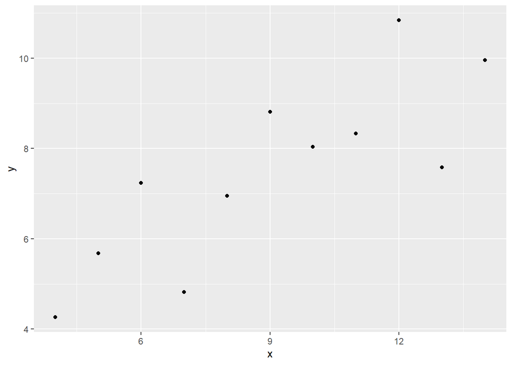

```r
a1 %>%
  ggplot(mapping = aes(x = x, y = y)) +
  geom_point()
```

Maybe you mapped the aesthetics within the `geom_point()` layer…

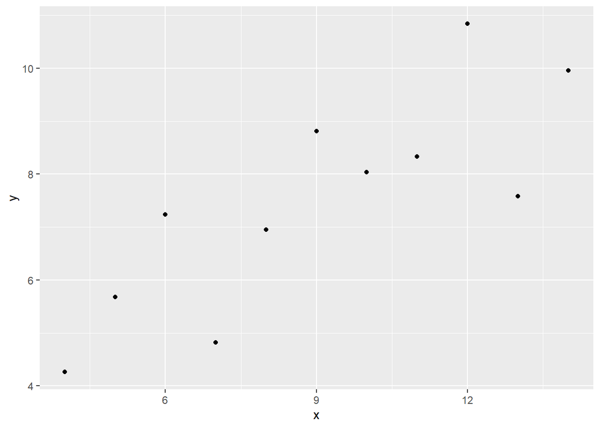

```r
a1 %>%
  ggplot() +
  geom_point(mapping = aes(x = x, y = y))
```

But…what happens if we did NOT map the `x` and `y` aesthetics?

The code below produces an error and is NOT executed or evaluated.

```r
a1 %>%
  ggplot() +
  geom_point()
```

Some more errors that can occur. Map the `x` aesthetic but forget the `y` aesthetic.

```r
### the code below produces an error and is commented out
# a1 %>%
#   ggplot(mapping = aes(x = x)) +
#   geom_point()
```

Same thing with the `y` aesthetic.

```r
### ERROR!!!
# a1 %>%
#   ggplot(mapping = aes(y = x)) +
#   geom_point()
```

What happens if we forget about the `aes()` function?

We need to include the aesthetics within the `aes()` function to instruct ggplot2 to “look” at the provided data. Without `aes()` it cannot find the variable.

The code chunk below results in an error.

```r
a1 %>%
  ggplot() +
  geom_point(x = x, y = y)
```

Let’s create a data set for the second Anscombe quarter data.

```r
a2 <- anscombe %>%
  select(ends_with('2')) %>%
  rename(x = x2, y = y2)
```

Create a scatter plot between `y` and `x` for the second quartet.

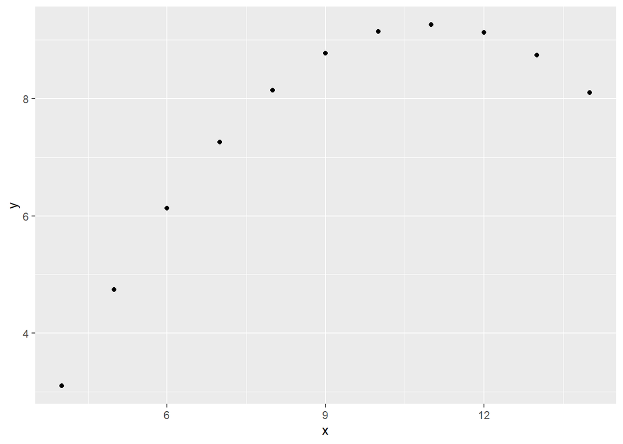

```r
a2 %>%
  ggplot(mapping = aes(x = x, y = y)) +
  geom_point()
```

How does `aes()` handle the other aesthetics.

Let’s make a scatterplot for the `a1` data set again but with blue markers.  
First, try setting the aesthetic, `color` WITHIN `aes()`.

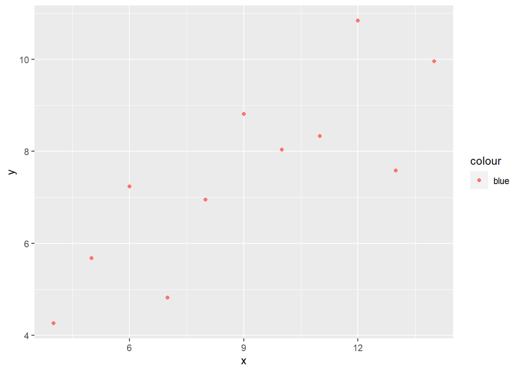

```r
a1 %>%
  ggplot(mapping = aes(x = x, y = y)) +
  geom_point(mapping = aes(color = 'blue'))
```

Assign the `color` outside of `aes()` within `geom_point()`.

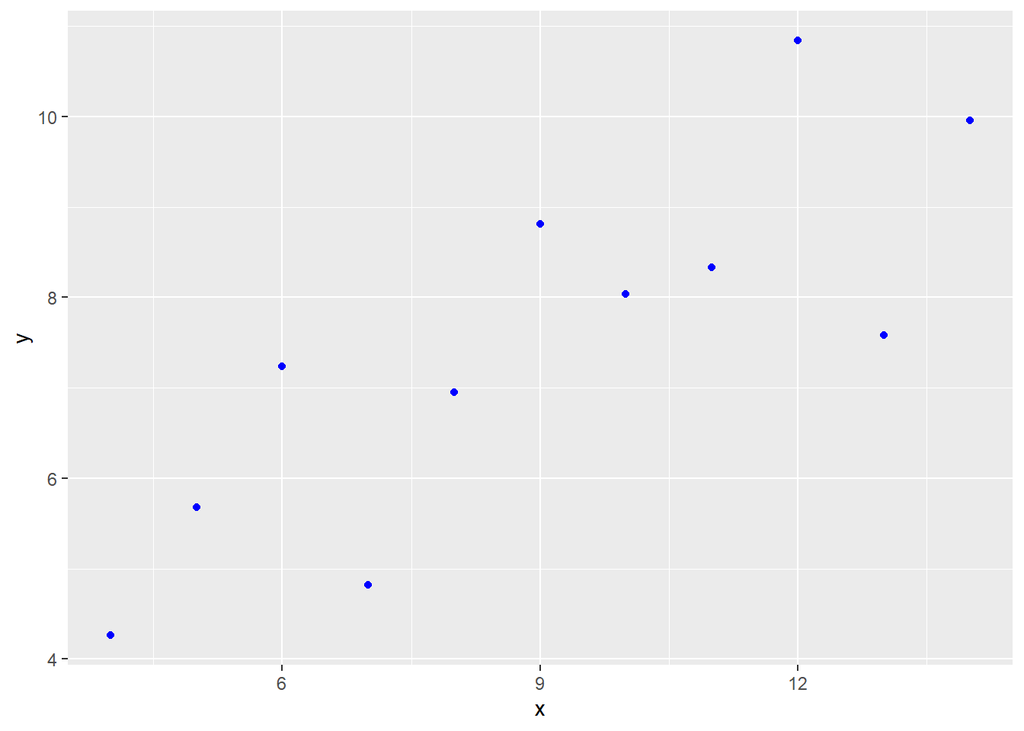

```r
a1 %>%
  ggplot(mapping = aes(x = x, y = y)) +
  geom_point(color = 'blue')
```

The `aes()` function wants to link or MAP or associate variable values to visual properties.

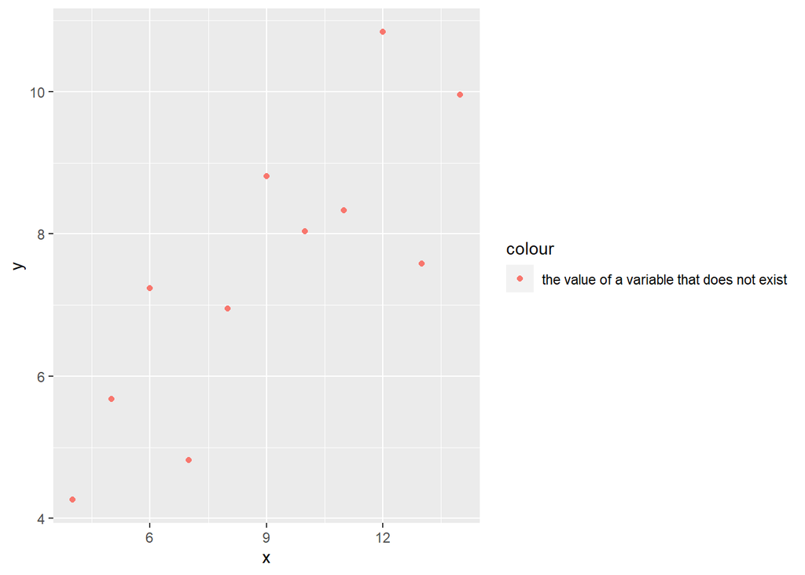

```r
a1 %>%
  ggplot(mapping = aes(x = x, y = y)) +
  geom_point(mapping = aes(color = 'the value of a variable that does not exist'))
```

If you want to HARD CODE a visual property do NOT use `aes()`.

Let’s map aesthetics to “manually defined variable values” to let us directly compare quartets within Anscombe.

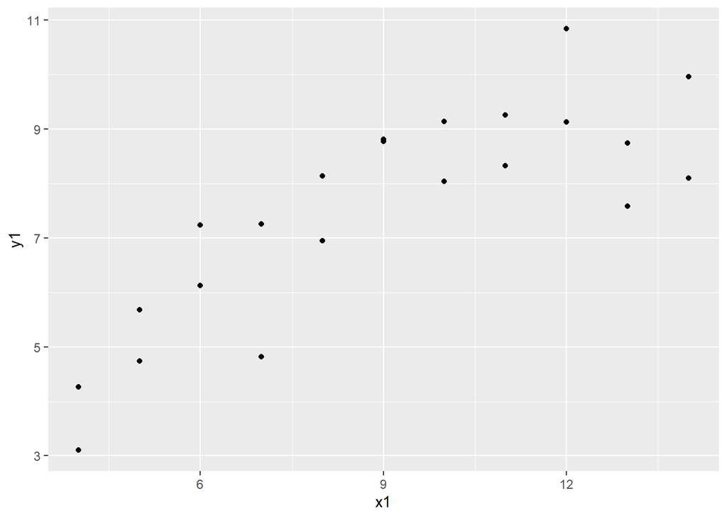

```r
anscombe %>%
  ggplot() +
  geom_point(mapping = aes(x = x1, y = y1)) +
  geom_point(mapping = aes(x = x2, y = y2))
```

Distinguish one data set from the other with color. First, do so by hard coding the colors outside `aes()`.

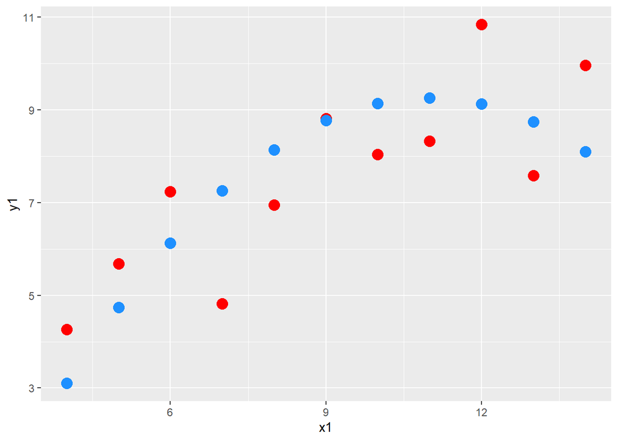

```r
anscombe %>%
  ggplot() +
  geom_point(mapping = aes(x = x1, y = y1),
             color = 'red', size = 4) +
  geom_point(mapping = aes(x = x2, y = y2),
             color = 'dodgerblue', size = 4)
```

Instead of hard coding we can define the color within `aes()` by “manually mapping to a variable”.

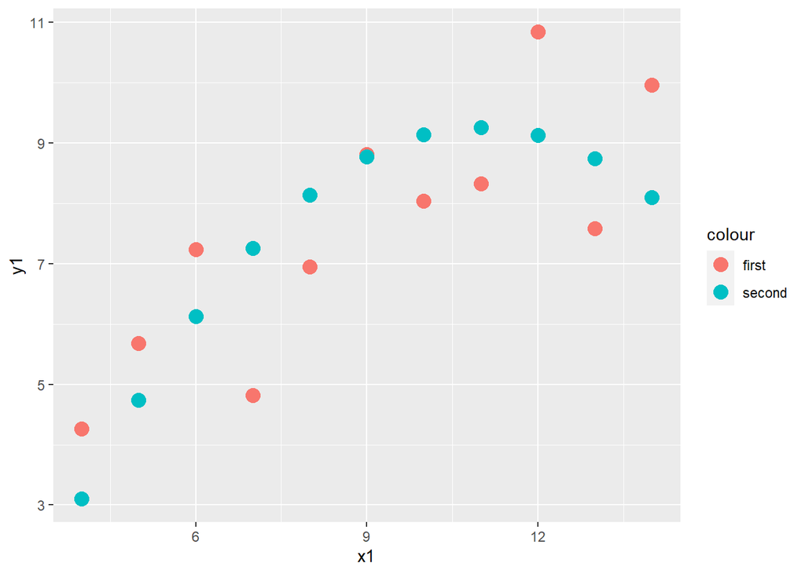

```r
anscombe %>%
  ggplot() +
  geom_point(mapping = aes(x = x1, y = y1,
                           color = 'first'),
             size = 4) +
  geom_point(mapping = aes(x = x2, y = y2,
                           color = 'second'),
             size = 4)
```

Change the legend guide LABEL with the `scale_` family functions.

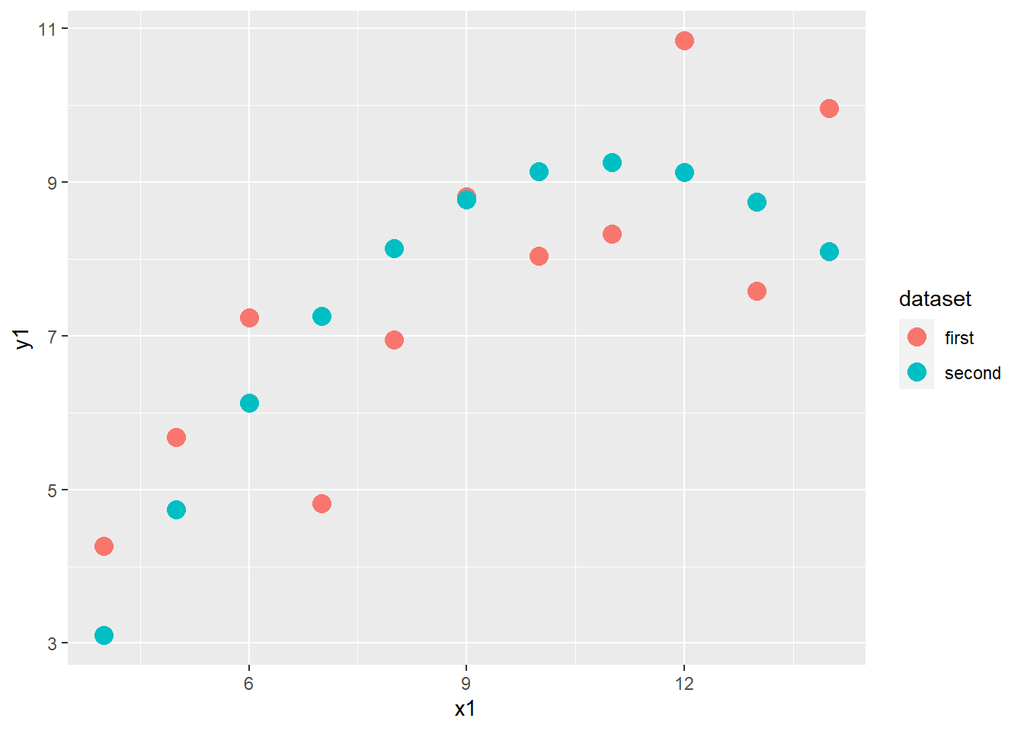

```r
anscombe %>%
  ggplot() +
  geom_point(mapping = aes(x = x1, y = y1,
                           color = 'first'),
             size = 4) +
  geom_point(mapping = aes(x = x2, y = y2,
                           color = 'second'),
             size = 4) +
  scale_color_discrete('dataset')
```

We can use a different categorical color scale if we’d like.

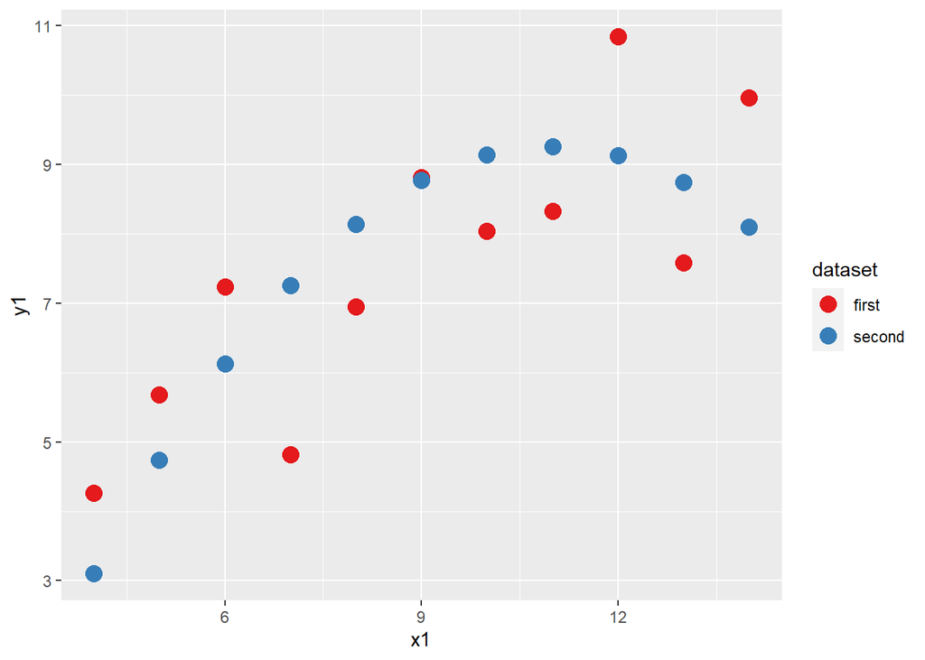

```r
anscombe %>%
  ggplot() +
  geom_point(mapping = aes(x = x1, y = y1,
                           color = 'first'),
             size = 4) +
  geom_point(mapping = aes(x = x2, y = y2,
                           color = 'second'),
             size = 4) +
  scale_color_brewer('dataset', palette = 'Set1')
```

We know the axis labels are not correct, so we can override with the `labs()` function.

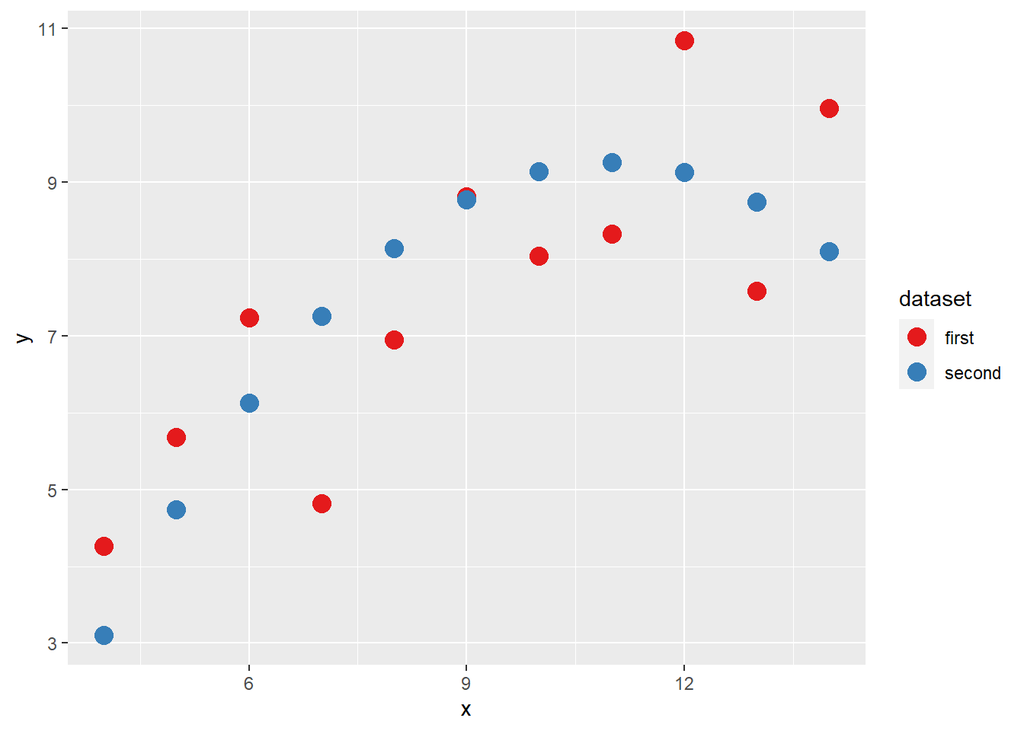

```r
anscombe %>%
  ggplot() +
  geom_point(mapping = aes(x = x1, y = y1,
                           color = 'first'),
             size = 4) +
  geom_point(mapping = aes(x = x2, y = y2,
                           color = 'second'),
             size = 4) +
  scale_color_brewer('dataset', palette = 'Set1') +
  labs(x = 'x', y = 'y')
```

Also use the marker shape to denote the dataset. Include the shape scale function so ggplot2 knows the variable being represented is the same as color.

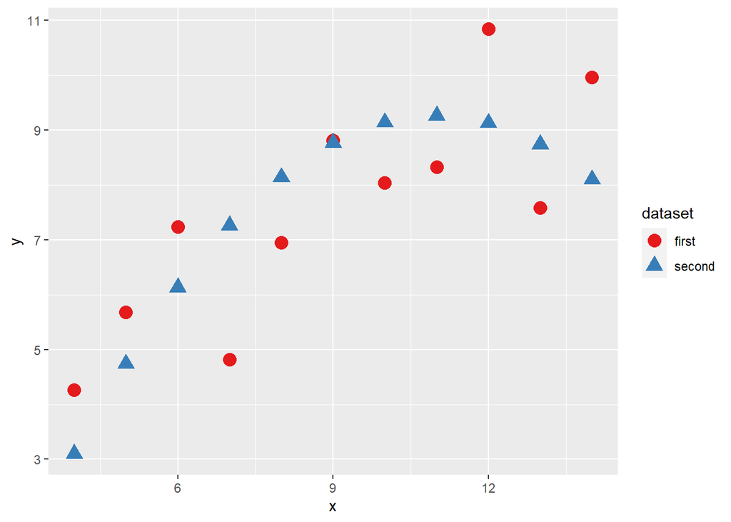

```r
anscombe %>%
  ggplot() +
  geom_point(mapping = aes(x = x1, y = y1,
                           color = 'first',
                           shape = 'first'),
             size = 4) +
  geom_point(mapping = aes(x = x2, y = y2,
                           color = 'second',
                           shape = 'second'),
             size = 4) +
  scale_color_brewer('dataset', palette = 'Set1') +
  scale_shape_discrete('dataset') +
  labs(x = 'x', y = 'y')
```

Instead of hard coding the marker size, link the marker size to a variable.

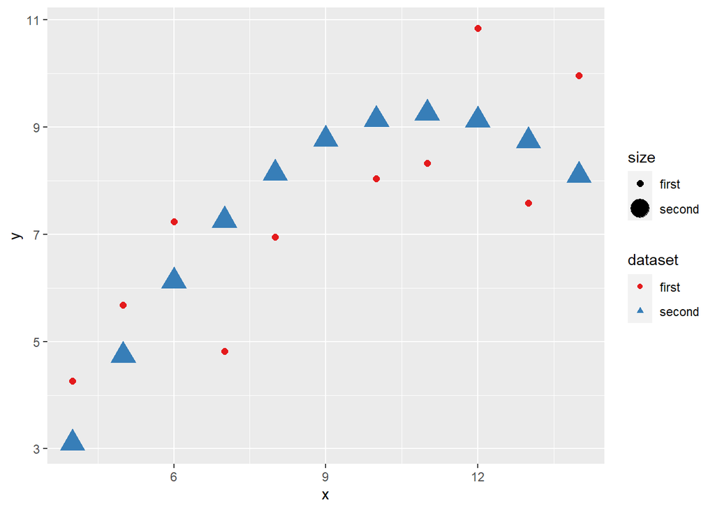

```r
anscombe %>%
  ggplot() +
  geom_point(mapping = aes(x = x1, y = y1,
                           color = 'first',
                           shape = 'first',
                           size = 'first')) +
  geom_point(mapping = aes(x = x2, y = y2,
                           color = 'second',
                           shape = 'second',
                           size = 'second')) +
  scale_color_brewer('dataset', palette = 'Set1') +
  scale_shape_discrete('dataset') +
  labs(x = 'x', y = 'y')
```

When we want to use `size` with a categorical we need to use a MANAUL scale.

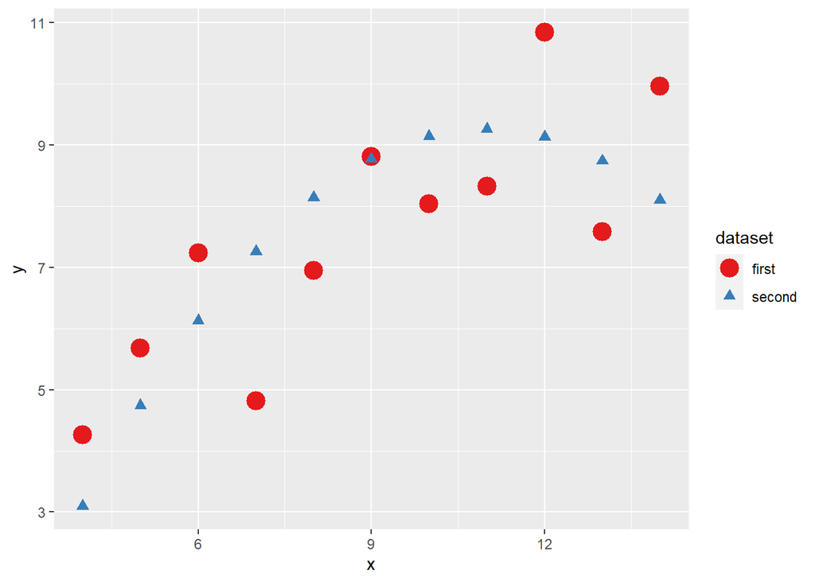

```r
anscombe %>%
  ggplot() +
  geom_point(mapping = aes(x = x1, y = y1,
                           color = 'first',
                           shape = 'first',
                           size = 'first')) +
  geom_point(mapping = aes(x = x2, y = y2,
                           color = 'second',
                           shape = 'second',
                           size = 'second')) +
  scale_color_brewer('dataset', palette = 'Set1') +
  scale_shape_discrete('dataset') +
  scale_size_manual('dataset',
                    values = c("first" = 5.5,
                               "second" = 2.5)) +
  labs(x = 'x', y = 'y')
```

We can also modify the marker transparency with the `alpha` aesthetic.

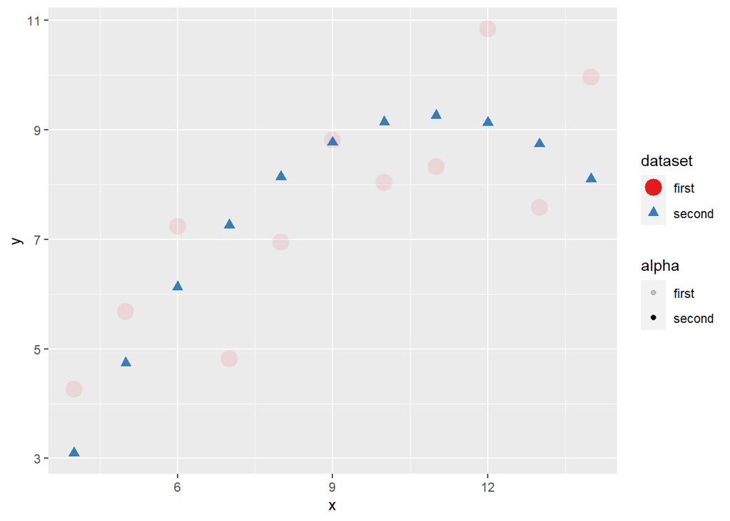

```r
anscombe %>%
  ggplot() +
  geom_point(mapping = aes(x = x1, y = y1,
                           color = 'first',
                           shape = 'first',
                           size = 'first',
                           alpha = 'first')) +
  geom_point(mapping = aes(x = x2, y = y2,
                           color = 'second',
                           shape = 'second',
                           size = 'second',
                           alpha = 'second')) +
  scale_color_brewer('dataset', palette = 'Set1') +
  scale_shape_discrete('dataset') +
  scale_size_manual('dataset',
                    values = c("first" = 5.5,
                               "second" = 2.5)) +
  labs(x = 'x', y = 'y')
```

We can use a manual scale to associate transpreancy with a categorical variable.

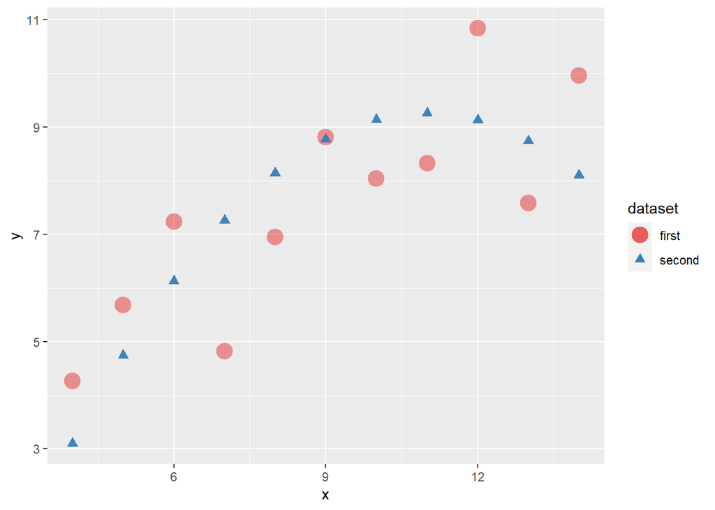

```r
anscombe %>%
  ggplot() +
  geom_point(mapping = aes(x = x1, y = y1,
                           color = 'first',
                           shape = 'first',
                           size = 'first',
                           alpha = 'first')) +
  geom_point(mapping = aes(x = x2, y = y2,
                           color = 'second',
                           shape = 'second',
                           size = 'second',
                           alpha = 'second')) +
  scale_color_brewer('dataset', palette = 'Set1') +
  scale_shape_discrete('dataset') +
  scale_size_manual('dataset',
                    values = c("first" = 5.5,
                               "second" = 2.5)) +
  scale_alpha_manual('dataset',
                     values = c('first' = 0.45,
                                'second' = 0.95)) +
  labs(x = 'x', y = 'y')
```

## 4 data sets

The 4 data sets are constructed to consider the **linear relationship** between `y` and `x`.

Let’s fit a linear model aka “the best fit line” between the output and input for each data set.

```r
mod_1 <- lm(y ~ x, data = a1)
```

```r
mod_1 %>% summary()
```

```
##
## Call:
## lm(formula = y ~ x, data = a1)
##
## Residuals:
##      Min       1Q   Median       3Q      Max
## -1.92127 -0.45577 -0.04136  0.70941  1.83882
##
## Coefficients:
##             Estimate Std. Error t value Pr(>|t|)
## (Intercept)   3.0001     1.1247   2.667  0.02573 *
## x             0.5001     0.1179   4.241  0.00217 **
## ---
## Signif. codes:  0 '***' 0.001 '**' 0.01 '*' 0.05 '.' 0.1 ' ' 1
##
## Residual standard error: 1.237 on 9 degrees of freedom
## Multiple R-squared:  0.6665, Adjusted R-squared:  0.6295
## F-statistic: 17.99 on 1 and 9 DF,  p-value: 0.00217
```

What are the coefficients? The intercept and slope?

```r
coef(mod_1)
```

```
## (Intercept)           x
##   3.0000909   0.5000909
```

```r
mod_1 %>% broom::tidy()
```

```
## # A tibble: 2 × 5
##   term        estimate std.error statistic p.value
##   <chr>          <dbl>     <dbl>     <dbl>   <dbl>
## 1 (Intercept)    3.00      1.12       2.67 0.0257
## 2 x              0.500     0.118      4.24 0.00217
```

Fit a linear model for the second data set.

```r
mod_2 <- lm(y ~ x, data = a2)

mod_2 %>% broom::tidy()
```

```
## # A tibble: 2 × 5
##   term        estimate std.error statistic p.value
##   <chr>          <dbl>     <dbl>     <dbl>   <dbl>
## 1 (Intercept)     3.00     1.13       2.67 0.0258
## 2 x               0.5      0.118      4.24 0.00218
```

Look at the R-squared.

```r
mod_1 %>% broom::glance()
```

```
## # A tibble: 1 × 12
##   r.squared adj.r.squared sigma statistic p.value    df logLik   AIC   BIC
##       <dbl>         <dbl> <dbl>     <dbl>   <dbl> <dbl>  <dbl> <dbl> <dbl>
## 1     0.667         0.629  1.24      18.0 0.00217     1  -16.8  39.7  40.9
## # … with 3 more variables: deviance <dbl>, df.residual <int>, nobs <int>
```

```r
mod_2 %>% broom::glance()
```

```
## # A tibble: 1 × 12
##   r.squared adj.r.squared sigma statistic p.value    df logLik   AIC   BIC
##       <dbl>         <dbl> <dbl>     <dbl>   <dbl> <dbl>  <dbl> <dbl> <dbl>
## 1     0.666         0.629  1.24      18.0 0.00218     1  -16.8  39.7  40.9
## # … with 3 more variables: deviance <dbl>, df.residual <int>, nobs <int>
```

## Visualize all 4 datasets

Tidy the `anscombe` data set.

```r
a_tidy <- anscombe %>%
  tibble::rowid_to_column() %>%
  pivot_longer(cols = !c("rowid")) %>%
  tidyr::separate(name,
                  c("variable", "dataset"),
                  sep = 1) %>%
  pivot_wider(names_from = 'variable', values_from = 'value') %>%
  arrange(dataset)
```

The tidy data long format data are consistent with the data from Seaborn.

```r
a_tidy %>% glimpse()
```

```
## Rows: 44
## Columns: 4
## $ rowid   <int> 1, 2, 3, 4, 5, 6, 7, 8, 9, 10, 11, 1, 2, 3, 4, 5, 6, 7, 8, 9, …
## $ dataset <chr> "1", "1", "1", "1", "1", "1", "1", "1", "1", "1", "1", "2", "2…
## $ x       <dbl> 10, 8, 13, 9, 11, 14, 6, 4, 12, 7, 5, 10, 8, 13, 9, 11, 14, 6,…
## $ y       <dbl> 8.04, 6.95, 7.58, 8.81, 8.33, 9.96, 7.24, 4.26, 10.84, 4.82, 5…
```

Use facets to show the different groups.

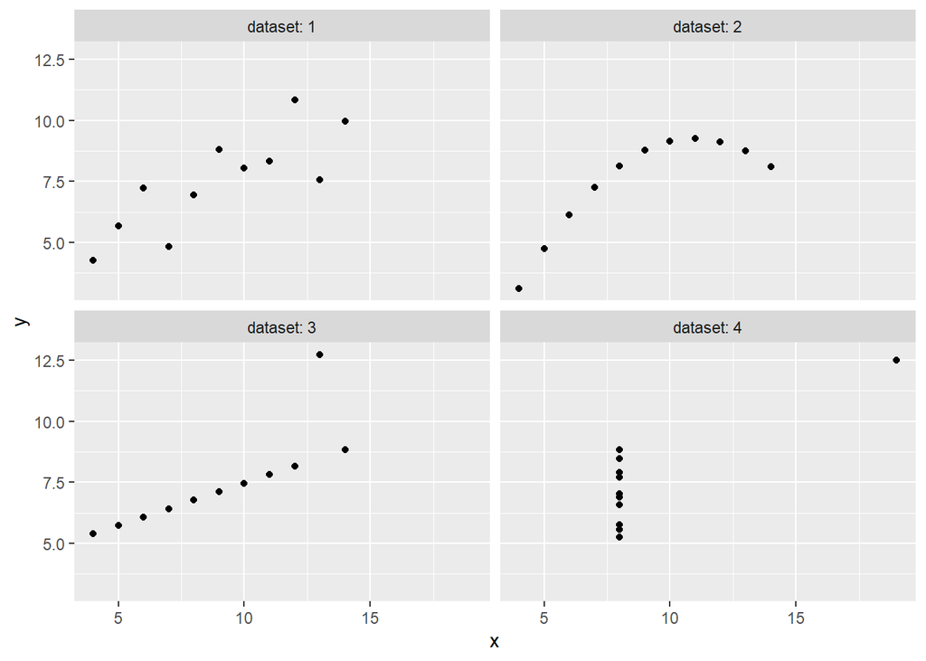

```r
a_tidy %>%
  ggplot(mapping = aes(x = x, y = y)) +
  geom_point() +
  facet_wrap(~dataset, labeller = 'label_both')
```

We can easily map any aesthetic to the `dataset` column.

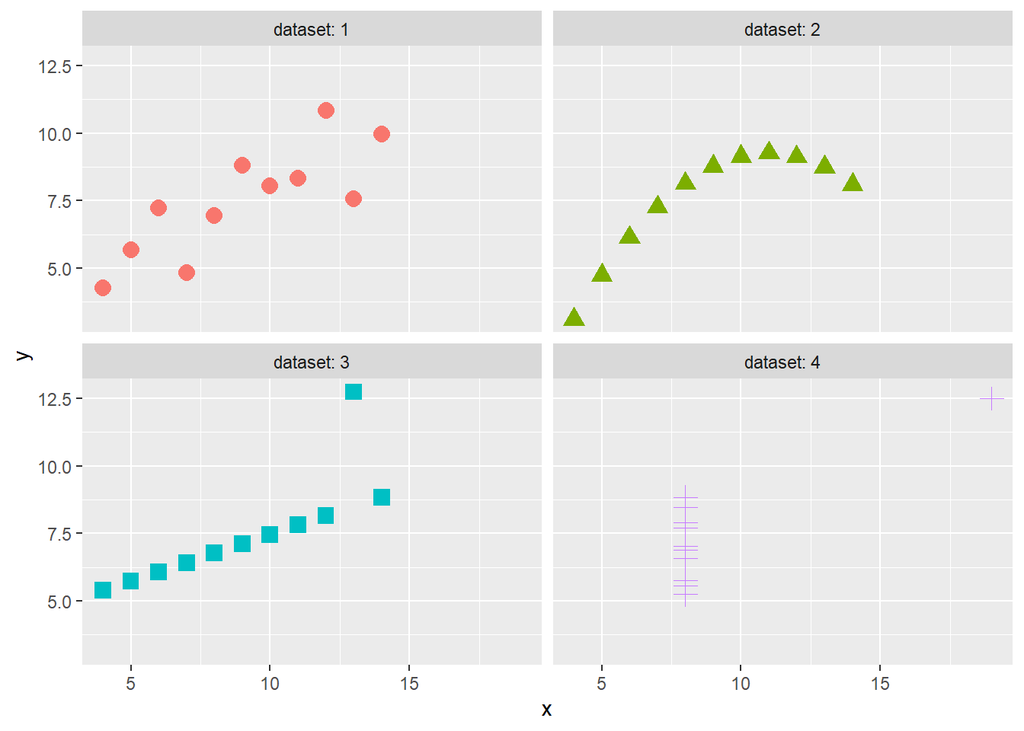

```r
a_tidy %>%
  ggplot(mapping = aes(x = x, y = y)) +
  geom_point(mapping = aes(color = dataset,
                           shape = dataset),
             size = 3.5) +
  facet_wrap(~dataset, labeller = 'label_both') +
  theme(legend.position = 'none')
```

We can easily add in the best fit line with another layer.

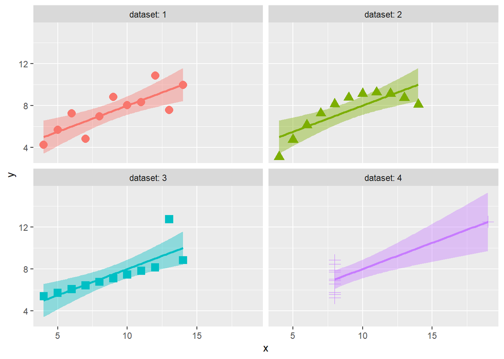

```r
a_tidy %>%
  ggplot(mapping = aes(x = x, y = y)) +
  geom_point(mapping = aes(color = dataset,
                           shape = dataset),
             size = 3.5) +
  geom_smooth(method = lm,
              formula = y ~ x,
              mapping = aes(color = dataset,
                            fill = dataset)) +
  facet_wrap(~dataset, labeller = 'label_both') +
  theme(legend.position = 'none')
```